# Python Project - Prosper Loan Dataset

## Introduction

This is the Dataset for Prosper Loan, a Loan investment company. For the purpose of this analysis, it will be referred to as 'df'

# Preliminary Wrangling

```python
import pandas as pd
```

```python
df = pd.read_csv('Prosper Loan.csv')
```

```python
df
```

|  | ListingKey | ListingNumber | ListingCreationDate | CreditGrade | Term | LoanStatus | ClosedDate | BorrowerAPR | BorrowerRate | LenderYield | ... | LP_ServiceFees | LP_CollectionFees | LP_GrossPrincipalLoss | LP_NetPrincipalLoss | LP_NonPrincipalRecoverypayments | PercentFunded | Recommendations | InvestmentFromFriendsCount | InvestmentFromFriendsAmount | Investors |
| --- | --- | --- | --- | --- | --- | --- | --- | --- | --- | --- | --- | --- | --- | --- | --- | --- | --- | --- | --- | --- | --- |
| 0 | 1021339766868145413AB3B | 193129 | 09:29.3 | C | 36 | Completed | 14/08/2009 00:00 | 0.16516 | 0.1580 | 0.1380 | ... | -133.18 | 0.0 | 0.0 | 0.0 | 0.0 | 1.0 | 0 | 0 | 0.0 | 258 |
| 1 | 10273602499503308B223C1 | 1209647 | 28:07.9 | NaN | 36 | Current | NaN | 0.12016 | 0.0920 | 0.0820 | ... | 0.00 | 0.0 | 0.0 | 0.0 | 0.0 | 1.0 | 0 | 0 | 0.0 | 1 |
| 2 | 0EE9337825851032864889A | 81716 | 00:47.1 | HR | 36 | Completed | 17/12/2009 00:00 | 0.28269 | 0.2750 | 0.2400 | ... | -24.20 | 0.0 | 0.0 | 0.0 | 0.0 | 1.0 | 0 | 0 | 0.0 | 41 |
| 3 | 0EF5356002482715299901A | 658116 | 02:35.0 | NaN | 36 | Current | NaN | 0.12528 | 0.0974 | 0.0874 | ... | -108.01 | 0.0 | 0.0 | 0.0 | 0.0 | 1.0 | 0 | 0 | 0.0 | 158 |
| 4 | 0F023589499656230C5E3E2 | 909464 | 38:39.1 | NaN | 36 | Current | NaN | 0.24614 | 0.2085 | 0.1985 | ... | -60.27 | 0.0 | 0.0 | 0.0 | 0.0 | 1.0 | 0 | 0 | 0.0 | 20 |
| ... | ... | ... | ... | ... | ... | ... | ... | ... | ... | ... | ... | ... | ... | ... | ... | ... | ... | ... | ... | ... | ... |
| 113932 | E6D9357655724827169606C | 753087 | 55:02.7 | NaN | 36 | Current | NaN | 0.22354 | 0.1864 | 0.1764 | ... | -75.58 | 0.0 | 0.0 | 0.0 | 0.0 | 1.0 | 0 | 0 | 0.0 | 1 |
| 113933 | E6DB353036033497292EE43 | 537216 | 42:55.3 | NaN | 36 | FinalPaymentInProgress | NaN | 0.13220 | 0.1110 | 0.1010 | ... | -30.05 | 0.0 | 0.0 | 0.0 | 0.0 | 1.0 | 0 | 0 | 0.0 | 22 |
| 113934 | E6E13596170052029692BB1 | 1069178 | 49:12.7 | NaN | 60 | Current | NaN | 0.23984 | 0.2150 | 0.2050 | ... | -16.91 | 0.0 | 0.0 | 0.0 | 0.0 | 1.0 | 0 | 0 | 0.0 | 119 |
| 113935 | E6EB3531504622671970D9E | 539056 | 18:26.6 | NaN | 60 | Completed | 13/08/2013 00:00 | 0.28408 | 0.2605 | 0.2505 | ... | -235.05 | 0.0 | 0.0 | 0.0 | 0.0 | 1.0 | 0 | 0 | 0.0 | 274 |
| 113936 | E6ED3600409833199F711B7 | 1140093 | 27:37.7 | NaN | 36 | Current | NaN | 0.13189 | 0.1039 | 0.0939 | ... | -1.70 | 0.0 | 0.0 | 0.0 | 0.0 | 1.0 | 0 | 0 | 0.0 | 1 |

113937 rows × 81 columns

# What is the structure of your dataset?

The Prosper Loan Dataset is stored and imported as a CSV file. It contains both Numerical data type(floating -points and interger) and a categorical data type (boolean).

# What is/are the main feature(s) of interest in your dataset?

Main Features are : Investors, Loan Status and Customer Demorgraphics

# What features in the dataset do you think will help support your investigation into your feature(s) of interest?

Features are: Loan Status: Principal Loss(Both Gross and Net),Estimated Loss, Estimated Return Investors : Number of Investors Customer Demorgraphics: Employment Status,Employment Status duration,Occupation,Borrower rate, Borrower APR

# Univariate Exploration

The exploration will be based on; Loan status distribution, Loan terms distribution, Interest rate distribution Customers occupation, ustomers employment status,

```python
df.info()
```

```
<class 'pandas.core.frame.DataFrame'>
RangeIndex: 113937 entries, 0 to 113936
Data columns (total 81 columns):
 #   Column                               Non-Null Count   Dtype
---  ------                               --------------   -----
 0   ListingKey                           113937 non-null  object
 1   ListingNumber                        113937 non-null  int64
 2   ListingCreationDate                  113937 non-null  object
 3   CreditGrade                          28953 non-null   object
 4   Term                                 113937 non-null  int64
 5   LoanStatus                           113937 non-null  object
 6   ClosedDate                           55089 non-null   object
 7   BorrowerAPR                          113912 non-null  float64
 8   BorrowerRate                         113937 non-null  float64
 9   LenderYield                          113937 non-null  float64
```

[output cut: 73 more lines]

```python
import matplotlib.pyplot as plt
```

```python
loan_status_counts = df['LoanStatus'].value_counts()
```

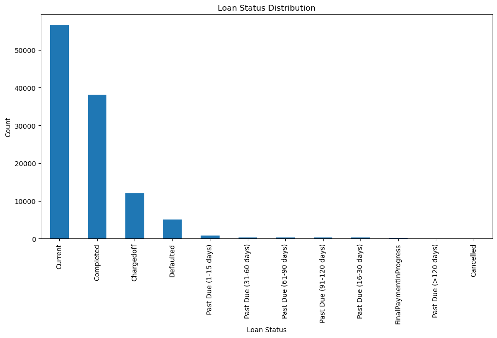

```python
plt.figure(figsize=(12, 6))
loan_status_counts.plot(kind='bar')
plt.xlabel('Loan Status')
plt.ylabel('Count')
plt.title('Loan Status Distribution')
plt.xticks(rotation=90)
plt.show()
```

```python
import seaborn as sns
import matplotlib.pyplot as plt
```

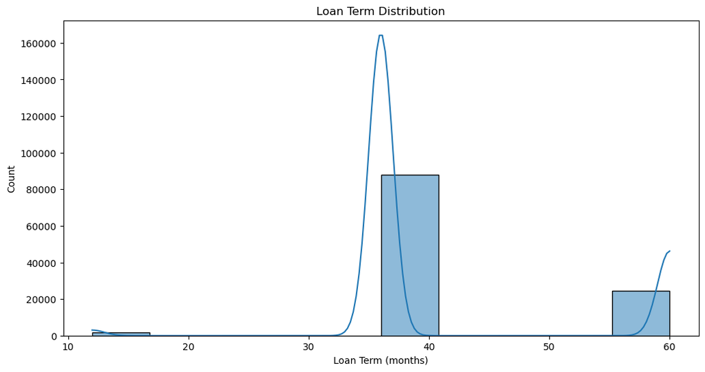

```python
plt.figure(figsize=(12, 6))
sns.histplot(data=df, x='Term', bins=10, kde=True)
plt.xlabel('Loan Term (months)')
plt.ylabel('Count')
plt.title('Loan Term Distribution')
plt.show()
```

```python
import seaborn as sns
import matplotlib.pyplot as plt
```

```python
employment_status_counts = df['EmploymentStatus'].value_counts()
```

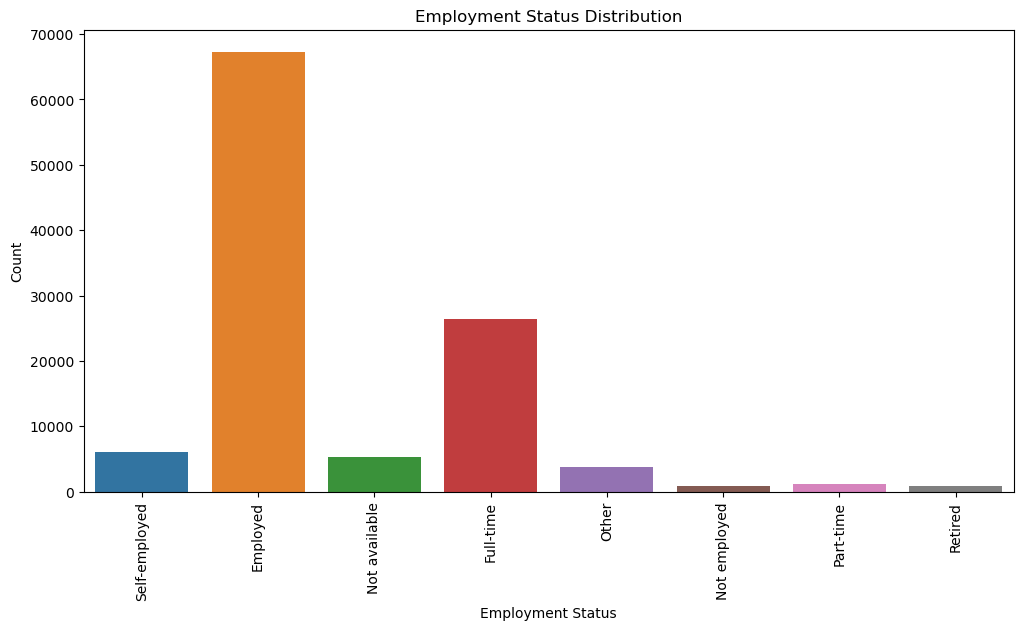

```python
plt.figure(figsize=(12, 6))
sns.countplot(data=df, x='EmploymentStatus')
plt.xticks(rotation=90)
plt.xlabel('Employment Status')
plt.ylabel('Count')
plt.title('Employment Status Distribution')
plt.show()
```

```python
import seaborn as sns
import matplotlib.pyplot as plt
```

```python
interest_rates = df['BorrowerRate']
```

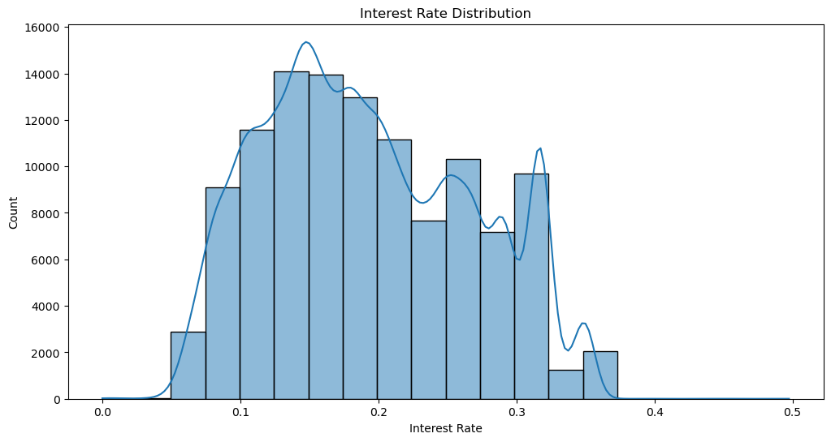

```python
plt.figure(figsize=(12, 6))
sns.histplot(data=interest_rates, bins=20, kde=True)
plt.xlabel('Interest Rate')
plt.ylabel('Count')
plt.title('Interest Rate Distribution')
plt.show()
```

```python
import seaborn as sns
import matplotlib.pyplot as plt
```

```python
occupation_counts = df['Occupation'].value_counts()
```

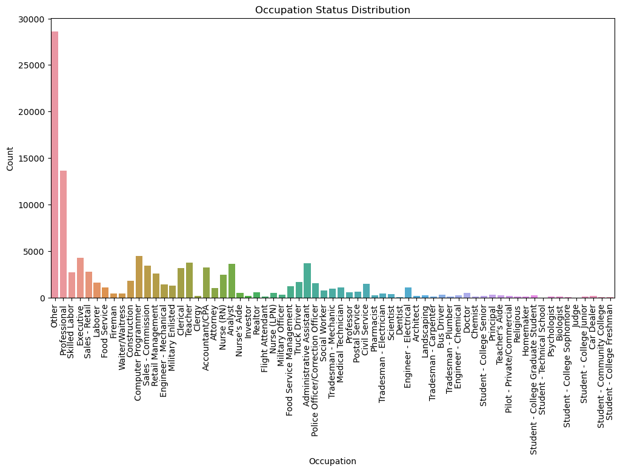

```python
plt.figure(figsize=(12, 6))
sns.countplot(data=df, x='Occupation')
plt.xticks(rotation=90)
plt.xlabel('Occupation')
plt.ylabel('Count')
plt.title('Occupation Status Distribution')
plt.show()
```

# Discuss the distribution(s) of your variable(s) of interest. Were there any unusual points? Did you need to perform any transformations?

Loan status distribution:

The loan status distribution provides information about the different categories of loan status in the dataset. It can help understand the proportion of loans that are current, completed, defaulted, etc.

Interest rate distribution:

The interest rate distribution shows the spread of interest rates for the loans in the dataset. It helps understand the range and frequency of different interest rates borrowers have been charged. Unusual points could be extreme values or outliers in the interest rates that are significantly different from the majority of the data.

Employment status of the customers:

This provides insights into the different categories of employment status for the customers. It helps understand the composition of the customer base in terms of employment status, such as employed, self-employed, unemployed, etc.

Occupation status Distribution of the customers:

This represents the different occupations or job categories of the customers. It helps understand the diversity of occupations within the customer base.

Loan term distribution:

This shows the spread of loan terms (in months) in the dataset. It helps understand the distribution of loan durations and the most common loan term lengths. Unusual points could be extreme loan term values or unexpected term lengths that deviate significantly from the majority of the data.

# Bivariate Exploration

Investigations will be based on the following: Loan Status and Interest Rate Employment Status and Loan Term Occupation Status and Loan Status Interest Rate and Loan Term

```python
df.info()
```

```
<class 'pandas.core.frame.DataFrame'>
RangeIndex: 113937 entries, 0 to 113936
Data columns (total 81 columns):
 #   Column                               Non-Null Count   Dtype
---  ------                               --------------   -----
 0   ListingKey                           113937 non-null  object
 1   ListingNumber                        113937 non-null  int64
 2   ListingCreationDate                  113937 non-null  object
 3   CreditGrade                          28953 non-null   object
 4   Term                                 113937 non-null  int64
 5   LoanStatus                           113937 non-null  object
 6   ClosedDate                           55089 non-null   object
 7   BorrowerAPR                          113912 non-null  float64
 8   BorrowerRate                         113937 non-null  float64
 9   LenderYield                          113937 non-null  float64
```

[output cut: 73 more lines]

```python
import seaborn as sns
import matplotlib.pyplot as plt
```

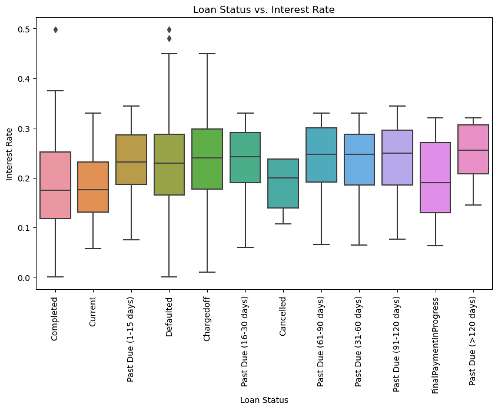

```python
plt.figure(figsize=(10, 6))
sns.boxplot(data=df, x='LoanStatus', y='BorrowerRate')
plt.xlabel('Loan Status')
plt.ylabel('Interest Rate')
plt.title('Loan Status vs. Interest Rate')
plt.xticks(rotation=90)
plt.show()
```

```python
import seaborn as sns
import matplotlib.pyplot as plt
```

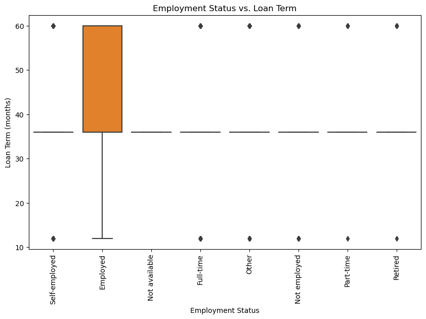

```python
plt.figure(figsize=(10, 6))
sns.boxplot(data=df, x='EmploymentStatus', y='Term')
plt.xlabel('Employment Status')
plt.ylabel('Loan Term (months)')
plt.title('Employment Status vs. Loan Term')
plt.xticks(rotation=90)
plt.show()
```

```python
import seaborn as sns
import matplotlib.pyplot as plt
```

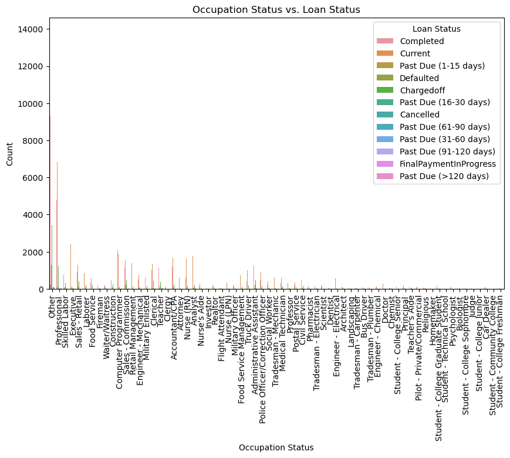

```python
plt.figure(figsize=(10, 6))
sns.countplot(data=df, x='Occupation', hue='LoanStatus')
plt.xlabel('Occupation Status')
plt.ylabel('Count')
plt.title('Occupation Status vs. Loan Status')
plt.xticks(rotation=90)
plt.legend(title='Loan Status')
plt.show()
```

```python
import seaborn as sns
import matplotlib.pyplot as plt
```

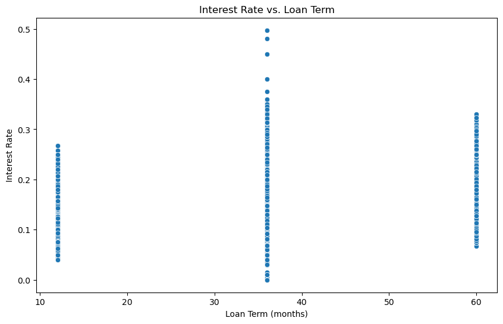

```python
plt.figure(figsize=(10, 6))
sns.scatterplot(data=df, x='Term', y='BorrowerRate')
plt.xlabel('Loan Term (months)')
plt.ylabel('Interest Rate')
plt.title('Interest Rate vs. Loan Term')
plt.show()
```

# Talk about some of the relationships you observed in this part of the investigation. How did the feature(s) of interest vary with other features in the dataset?

Loan Status and Interest Rate:

The distribution of interest rates differs across loan statuses, indicating that interest rates play a role in determining the likelihood of loan default or successful repayment.

Employment Status and Loan Term:

It is possible to observe specific patterns, such as individuals with certain employment statuses tending to opt for shorter or longer loan terms.

Occupation Status and Loan Status:

The relationship between occupation status and loan status provides insights into the loan outcomes for borrowers from different occupations.

Interest Rate and Loan Term:

The visualization helps to identify any trends or associations between interest rate and loan term, which can be useful for understanding borrowing costs and repayment strategies.

# Observations and Conclusion

These observations highlight the interplay between various features in the dataset and how they can influence loan outcomes, borrowing preferences, and the cost of borrowing. Further analysis and exploration of these relationships can provide deeper insights into the factors affecting loan status, interest rates, loan terms, and borrower characteristics.